# Census Tract Event Rate and Community Deprivation

Cole Brokamp

## Census API Key

Before you run this script, you will need to add your Census API key below.

```r
tidycensus::census_api_key("PASTE YOUR KEY HERE", install = TRUE)
```

Setting `install =` to `TRUE` will store your API key in your `.Renviron` to so that it is available in future sessions.

## Importing Data

```r
library(tidyverse)
library(sf)
```

Read in case data coordinates file and convert to `sf` object.

```r
raw_data <- read_csv('./simulated_case_locations.csv')

d_events <- st_as_sf(raw_data, coords = c('X', 'Y')) %>%
    st_set_crs(4326)
```

Quick check on event data.

```r
mapview::mapview(d_events)
```

Get the census tract geometries for Hamilton County.

```r
library(tigris)
options(tigris_class = "sf")
options(tigris_use_cache = TRUE)
```

```r
hamilton_tracts <- tracts(state = 39, county = 061) %>%
    select(GEOID)
```

Assign the corresponding census tract to each case location. We will transform both data sets into the “Ohio South” projection system.

```r
d_events <- st_transform(d_events, 3735)
hamilton_tracts <- st_transform(hamilton_tracts, 3735)
d_events <- st_join(d_events, hamilton_tracts)
```

Summarize the number of events at the census tract level.

```r
d_tracts <- d_events %>%
    group_by(GEOID) %>%
    summarize(n_events = n()) %>%
    st_set_geometry(NULL)
```

## Calculating the Event Rate

First, get the number of children per tract from the American Community Survey.

```r
d_pop <- tidycensus::get_acs(geography = 'tract',
                             variables = 'B09001_001E',
                             year = 2016,
                             state = 39, county = 61,
                             geometry = TRUE) %>%
    select(GEOID, n_children = estimate)
```

Merge in the number of events per tract and then calculate the event rate per 1,000 children in each tract.

```r
d <- left_join(d_pop, d_tracts, by = 'GEOID') %>%
    mutate(event_rate = n_events / n_children * 1000)
```

Plot our event rate for each census tract.

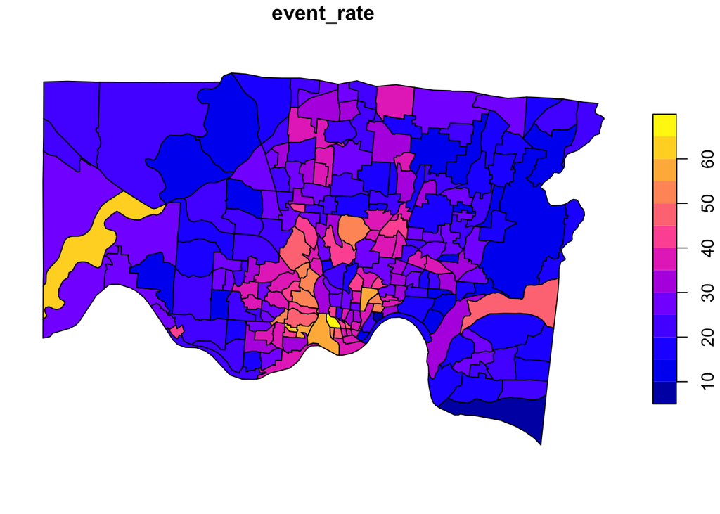

```r
plot(d['event_rate'])
```

## Association with Deprivation Index

Merge in our deprivation index and look at the relationship with the event rate.

```r
d_dep <- 'https://github.com/cole-brokamp/dep_index/raw/master/ACS_deprivation_index_by_census_tracts.rds' %>%
  url() %>%
  gzcon() %>%
  readRDS() %>%
  as_tibble() %>%
  select(GEOID = census_tract_fips, dep_index)

d <- left_join(d, d_dep, by='GEOID')
```

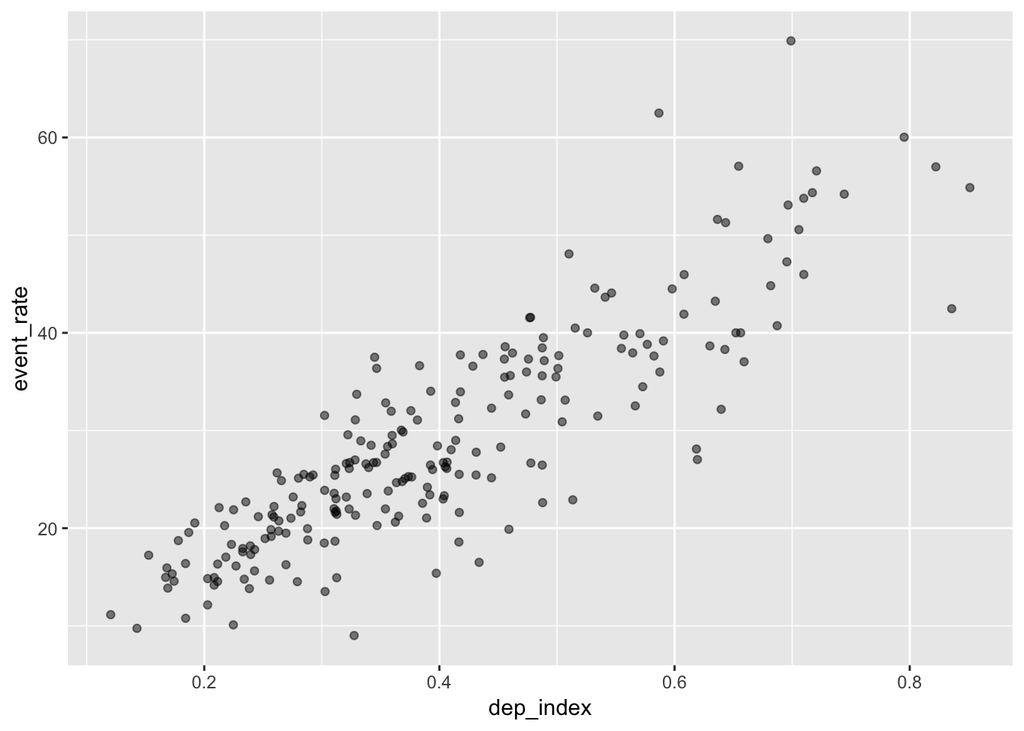

```r
ggplot(d, aes(dep_index, event_rate)) +
    geom_point(alpha = 0.5)
```

Spearman’s rank correlation between the tract-level deprivation index and event rate.

```r
cor.test(d$dep_index, d$event_rate, method = 'spearman')

    Spearman's rank correlation rho

data:  d$dep_index and d$event_rate
S = 244670, p-value < 2.2e-16
alternative hypothesis: true rho is not equal to 0
sample estimates:
     rho
0.865824
```

## Creating Side By Side Publication Ready Maps

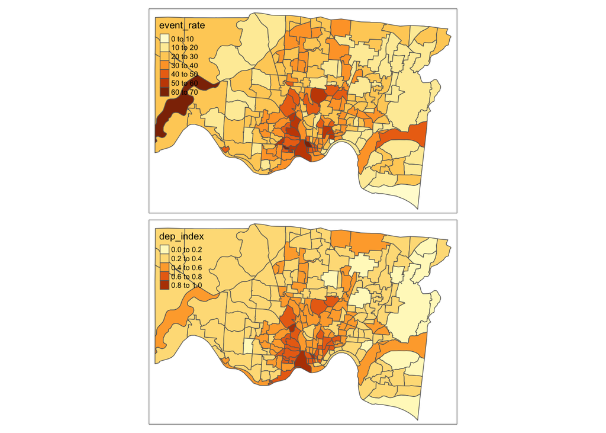

```r
library(tmap)
tmap_mode('plot')

d %>%
    tm_shape(projection = 4326) +
    tm_polygons(c('event_rate', 'dep_index'))
```

Now let’s pretty up our maps.

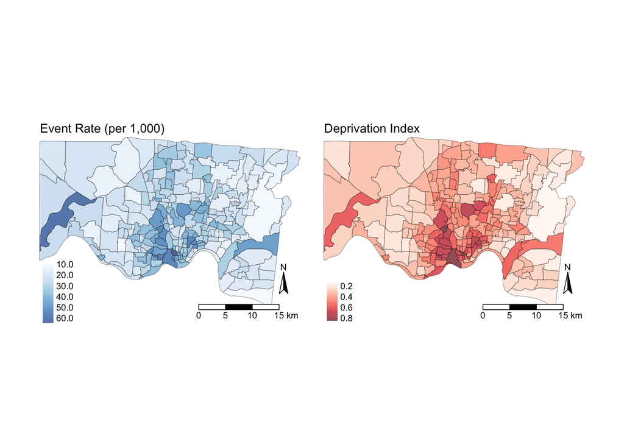

```r
d %>%
    tm_shape(projection = 4326) +
        tm_polygons(c('event_rate', 'dep_index'),
                    alpha = 0.7,
                    style = 'cont',
                    palette = list('Blues', 'Reds'),
                    title = c('', '', '', ''),
                    showNA = FALSE,
                    lwd = 0.3,
                    border.col = "black", border.alpha = 1) +
    tm_compass(position=c('right', 'bottom')) +
    tm_scale_bar(position = c('right', 'bottom'), size=0.8) +
    tm_layout(title = c('Event Rate (per 1,000)',
                        'Deprivation Index'),
              title.position = c("left", "top"),
              title.size = 1.1,
              legend.position = c("left", "bottom"),
              legend.format = list(digits = 1),
              frame = FALSE,
              legend.text.size=0.8,
              inner.margins = c(0.11, 0.03, 0.12, 0.03), # bottom, left, top, right
              outer.margins = c(0, 0.05, 0, 0.05))
```

An interactive version of the maps.

```r
ttm()
tmap_last()
```

[interactive chart not shown]